# 07-RLM

```python
import pandas as pd
import numpy as np
import seaborn as sns
import matplotlib.pyplot as plt
import statsmodels.api as sm
```

```python
todo=pd.read_csv("data/LifeExpectancyData.csv")
```

```python
todo.info()
```

```
<class 'pandas.core.frame.DataFrame'>
RangeIndex: 2938 entries, 0 to 2937
Data columns (total 22 columns):
 #   Column                           Non-Null Count  Dtype
---  ------                           --------------  -----
 0   Country                          2938 non-null   object
 1   Year                             2938 non-null   int64
 2   Status                           2938 non-null   object
 3   Life expectancy                  2928 non-null   float64
 4   Adult Mortality                  2928 non-null   float64
 5   infant deaths                    2938 non-null   int64
 6   Alcohol                          2744 non-null   float64
 7   percentage expenditure           2938 non-null   float64
 8   Hepatitis B                      2385 non-null   float64
 9   Measles                          2938 non-null   int64
 10   BMI                             2904 non-null   float64
 11  under-five deaths                2938 non-null   int64
 12  Polio                            2919 non-null   float64
 13  Total expenditure                2712 non-null   float64
 14  Diphtheria                       2919 non-null   float64
 15   HIV/AIDS                        2938 non-null   float64
 16  GDP                              2490 non-null   float64
 17  Population                       2286 non-null   float64
 18   thinness  1-19 years            2904 non-null   float64
 19   thinness 5-9 years              2904 non-null   float64
 20  Income composition of resources  2771 non-null   float64
 21  Schooling                        2775 non-null   float64
dtypes: float64(16), int64(4), object(2)
memory usage: 505.1+ KB
```

```python
todo.head(20)
```

|  | Country | Year | Status | Life expectancy | Adult Mortality | infant deaths | Alcohol | percentage expenditure | Hepatitis B | Measles | ... | Polio | Total expenditure | Diphtheria | HIV/AIDS | GDP | Population | thinness 1-19 years | thinness 5-9 years | Income composition of resources | Schooling |
| --- | --- | --- | --- | --- | --- | --- | --- | --- | --- | --- | --- | --- | --- | --- | --- | --- | --- | --- | --- | --- | --- |
| 0 | Afghanistan | 2015 | Developing | 65.0 | 263.0 | 62 | 0.01 | 71.279624 | 65.0 | 1154 | ... | 6.0 | 8.16 | 65.0 | 0.1 | 584.259210 | 33736494.0 | 17.2 | 17.3 | 0.479 | 10.1 |
| 1 | Afghanistan | 2014 | Developing | 59.9 | 271.0 | 64 | 0.01 | 73.523582 | 62.0 | 492 | ... | 58.0 | 8.18 | 62.0 | 0.1 | 612.696514 | 327582.0 | 17.5 | 17.5 | 0.476 | 10.0 |
| 2 | Afghanistan | 2013 | Developing | 59.9 | 268.0 | 66 | 0.01 | 73.219243 | 64.0 | 430 | ... | 62.0 | 8.13 | 64.0 | 0.1 | 631.744976 | 31731688.0 | 17.7 | 17.7 | 0.470 | 9.9 |
| 3 | Afghanistan | 2012 | Developing | 59.5 | 272.0 | 69 | 0.01 | 78.184215 | 67.0 | 2787 | ... | 67.0 | 8.52 | 67.0 | 0.1 | 669.959000 | 3696958.0 | 17.9 | 18.0 | 0.463 | 9.8 |
| 4 | Afghanistan | 2011 | Developing | 59.2 | 275.0 | 71 | 0.01 | 7.097109 | 68.0 | 3013 | ... | 68.0 | 7.87 | 68.0 | 0.1 | 63.537231 | 2978599.0 | 18.2 | 18.2 | 0.454 | 9.5 |
| 5 | Afghanistan | 2010 | Developing | 58.8 | 279.0 | 74 | 0.01 | 79.679367 | 66.0 | 1989 | ... | 66.0 | 9.20 | 66.0 | 0.1 | 553.328940 | 2883167.0 | 18.4 | 18.4 | 0.448 | 9.2 |
| 6 | Afghanistan | 2009 | Developing | 58.6 | 281.0 | 77 | 0.01 | 56.762217 | 63.0 | 2861 | ... | 63.0 | 9.42 | 63.0 | 0.1 | 445.893298 | 284331.0 | 18.6 | 18.7 | 0.434 | 8.9 |
| 7 | Afghanistan | 2008 | Developing | 58.1 | 287.0 | 80 | 0.03 | 25.873925 | 64.0 | 1599 | ... | 64.0 | 8.33 | 64.0 | 0.1 | 373.361116 | 2729431.0 | 18.8 | 18.9 | 0.433 | 8.7 |
| 8 | Afghanistan | 2007 | Developing | 57.5 | 295.0 | 82 | 0.02 | 10.910156 | 63.0 | 1141 | ... | 63.0 | 6.73 | 63.0 | 0.1 | 369.835796 | 26616792.0 | 19.0 | 19.1 | 0.415 | 8.4 |
| 9 | Afghanistan | 2006 | Developing | 57.3 | 295.0 | 84 | 0.03 | 17.171518 | 64.0 | 1990 | ... | 58.0 | 7.43 | 58.0 | 0.1 | 272.563770 | 2589345.0 | 19.2 | 19.3 | 0.405 | 8.1 |
| 10 | Afghanistan | 2005 | Developing | 57.3 | 291.0 | 85 | 0.02 | 1.388648 | 66.0 | 1296 | ... | 58.0 | 8.70 | 58.0 | 0.1 | 25.294130 | 257798.0 | 19.3 | 19.5 | 0.396 | 7.9 |
| 11 | Afghanistan | 2004 | Developing | 57.0 | 293.0 | 87 | 0.02 | 15.296066 | 67.0 | 466 | ... | 5.0 | 8.79 | 5.0 | 0.1 | 219.141353 | 24118979.0 | 19.5 | 19.7 | 0.381 | 6.8 |
| 12 | Afghanistan | 2003 | Developing | 56.7 | 295.0 | 87 | 0.01 | 11.089053 | 65.0 | 798 | ... | 41.0 | 8.82 | 41.0 | 0.1 | 198.728544 | 2364851.0 | 19.7 | 19.9 | 0.373 | 6.5 |
| 13 | Afghanistan | 2002 | Developing | 56.2 | 3.0 | 88 | 0.01 | 16.887351 | 64.0 | 2486 | ... | 36.0 | 7.76 | 36.0 | 0.1 | 187.845950 | 21979923.0 | 19.9 | 2.2 | 0.341 | 6.2 |
| 14 | Afghanistan | 2001 | Developing | 55.3 | 316.0 | 88 | 0.01 | 10.574728 | 63.0 | 8762 | ... | 35.0 | 7.80 | 33.0 | 0.1 | 117.496980 | 2966463.0 | 2.1 | 2.4 | 0.340 | 5.9 |
| 15 | Afghanistan | 2000 | Developing | 54.8 | 321.0 | 88 | 0.01 | 10.424960 | 62.0 | 6532 | ... | 24.0 | 8.20 | 24.0 | 0.1 | 114.560000 | 293756.0 | 2.3 | 2.5 | 0.338 | 5.5 |
| 16 | Albania | 2015 | Developing | 77.8 | 74.0 | 0 | 4.60 | 364.975229 | 99.0 | 0 | ... | 99.0 | 6.00 | 99.0 | 0.1 | 3954.227830 | 28873.0 | 1.2 | 1.3 | 0.762 | 14.2 |
| 17 | Albania | 2014 | Developing | 77.5 | 8.0 | 0 | 4.51 | 428.749067 | 98.0 | 0 | ... | 98.0 | 5.88 | 98.0 | 0.1 | 4575.763787 | 288914.0 | 1.2 | 1.3 | 0.761 | 14.2 |
| 18 | Albania | 2013 | Developing | 77.2 | 84.0 | 0 | 4.76 | 430.876979 | 99.0 | 0 | ... | 99.0 | 5.66 | 99.0 | 0.1 | 4414.723140 | 289592.0 | 1.3 | 1.4 | 0.759 | 14.2 |
| 19 | Albania | 2012 | Developing | 76.9 | 86.0 | 0 | 5.14 | 412.443356 | 99.0 | 9 | ... | 99.0 | 5.59 | 99.0 | 0.1 | 4247.614380 | 2941.0 | 1.3 | 1.4 | 0.752 | 14.2 |

20 rows × 22 columns

- Country:Country name
- Year: Year of the data
- Status: Country status of developed or developing
- Life_Expectancy: Life expectancy in age
- Adult_Mortality: Adult Mortality Rates of both sexes (probability of dying between 15 and 60 years per 1000 population)
- infant.deaths: Number of Infant Deaths per 1000 population
- Alcohol: Alcohol, recorded per capita (15+) consumption (in litres of pure alcohol)
- percentage.expenditure: Expenditure on health as a percentage of Gross Domestic Product per capita(%)
- Hepatitis.B: Hepatitis B (HepB) immunization coverage among 1-year-olds (%)
- Measles: number of reported cases per 1000 population
- BMI: Average Body Mass Index of entire population
- under.five.deaths: Number of under-five deaths per 1000 population
- Polio: Polio (Pol3) immunization coverage among 1-year-olds (%)
- Total.expenditure: General government expenditure on health as a percentage of total government expenditure (%)
- Diphtheria: Diphtheria tetanus toxoid and pertussis (DTP3) immunization coverage among 1-year-olds (%)room)
- HIV.AIDS: Deaths per 1 000 live births HIV/AIDS (0-4 years)
- GDP: Gross Domestic Product per capita (in USD)
- Population: Population of the country
- thinness..1.19.years: Prevalence of thinness among children and adolescents for Age 10 to 19 (% )
- thinness.5.9.years: Prevalence of thinness among children for Age 5 to 9(%)
- Income.composition.of.resources: Human Development Index in terms of income composition of resources (index ranging from 0 to 1)
- Schooling: Number of years of Schooling(years)

```python
data2010 = todo[todo['Year'] == 2010]
```

```python
data2010.isna().sum()
```

```
Country                             0
Year                                0
Status                              0
Life expectancy                     0
Adult Mortality                     0
infant deaths                       0
Alcohol                             1
percentage expenditure              0
Hepatitis B                        15
Measles                             0
 BMI                                2
under-five deaths                   0
Polio                               1
Total expenditure                   3
Diphtheria                          1
 HIV/AIDS                           0
GDP                                27
Population                         40
 thinness  1-19 years               2
 thinness 5-9 years                 2
Income composition of resources    10
Schooling                          10
dtype: int64
```

```python
data2010[data2010["Population"].isna()].head(10)
```

|  | Country | Year | Status | Life expectancy | Adult Mortality | infant deaths | Alcohol | percentage expenditure | Hepatitis B | Measles | ... | Polio | Total expenditure | Diphtheria | HIV/AIDS | GDP | Population | thinness 1-19 years | thinness 5-9 years | Income composition of resources | Schooling |
| --- | --- | --- | --- | --- | --- | --- | --- | --- | --- | --- | --- | --- | --- | --- | --- | --- | --- | --- | --- | --- | --- |
| 69 | Antigua and Barbuda | 2010 | Developing | 75.6 | 138.0 | 0 | 7.84 | 1983.956937 | 98.0 | 0 | ... | 99.0 | 5.63 | 98.0 | 0.1 | 12126.87614 | NaN | 3.3 | 3.3 | 0.783 | 14.1 |
| 165 | Bahamas | 2010 | Developing | 75.0 | 161.0 | 0 | 9.19 | 0.000000 | 98.0 | 0 | ... | 97.0 | 7.44 | 99.0 | 0.2 | NaN | NaN | 2.5 | 2.5 | 0.788 | 12.6 |
| 181 | Bahrain | 2010 | Developing | 76.1 | 73.0 | 0 | 1.93 | 266.769612 | 99.0 | 0 | ... | 99.0 | 3.64 | 99.0 | 0.1 | 2722.13890 | NaN | 6.0 | 5.9 | 0.810 | 14.4 |
| 213 | Barbados | 2010 | Developing | 74.7 | 16.0 | 0 | 8.41 | 154.963086 | 86.0 | 0 | ... | 9.0 | 6.17 | 86.0 | 0.1 | 1595.91232 | NaN | 3.8 | 3.8 | 0.781 | 15.8 |
| 309 | Bolivia (Plurinational State of) | 2010 | Developing | 68.7 | 22.0 | 9 | 3.95 | 0.000000 | 91.0 | 0 | ... | 9.0 | 5.44 | 91.0 | 0.2 | NaN | NaN | 1.2 | 1.1 | 0.643 | 13.8 |
| 373 | Brunei Darussalam | 2010 | Developing | 76.9 | 79.0 | 0 | 0.88 | 2218.364226 | 96.0 | 0 | ... | 99.0 | 2.73 | 95.0 | 0.1 | 35268.11170 | NaN | 5.9 | 5.4 | 0.845 | 14.2 |
| 437 | Côte d'Ivoire | 2010 | Developing | 51.5 | 417.0 | 60 | 3.15 | 0.000000 | 85.0 | 441 | ... | 81.0 | 6.32 | 85.0 | 3.3 | NaN | NaN | 6.3 | 6.2 | NaN | NaN |
| 613 | Congo | 2010 | Developing | 62.0 | 298.0 | 7 | 3.53 | 0.000000 | 74.0 | 4 | ... | 72.0 | 2.29 | 74.0 | 3.8 | NaN | NaN | 8.1 | 7.7 | 0.548 | 10.5 |
| 662 | Cuba | 2010 | Developing | 78.0 | 98.0 | 1 | 4.13 | 787.280816 | 96.0 | 0 | ... | 99.0 | 1.19 | 96.0 | 0.1 | 5676.14143 | NaN | 3.4 | 3.2 | 0.784 | 17.6 |
| 694 | Czechia | 2010 | Developed | 77.5 | 99.0 | 0 | 12.69 | 0.000000 | 99.0 | 0 | ... | 99.0 | 7.43 | 99.0 | 0.1 | NaN | NaN | 1.9 | 2.0 | NaN | NaN |

10 rows × 22 columns

```python
data2010 = data2010.dropna(subset=['Population',"Hepatitis B","GDP"," thinness  1-19 years"," thinness 5-9 years"]).drop(columns=['Country', 'Year'])
```

```python
data2010['Status'] = np.where(data2010['Status'] == "Developing", 1, 0)
```

```python
data2010.info()
data2010= data2010.reset_index()
```

```
<class 'pandas.core.frame.DataFrame'>
Int64Index: 128 entries, 5 to 2927
Data columns (total 20 columns):
 #   Column                           Non-Null Count  Dtype
---  ------                           --------------  -----
 0   Status                           128 non-null    int32
 1   Life expectancy                  128 non-null    float64
 2   Adult Mortality                  128 non-null    float64
 3   infant deaths                    128 non-null    int64
 4   Alcohol                          128 non-null    float64
 5   percentage expenditure           128 non-null    float64
 6   Hepatitis B                      128 non-null    float64
 7   Measles                          128 non-null    int64
 8    BMI                             128 non-null    float64
 9   under-five deaths                128 non-null    int64
 10  Polio                            128 non-null    float64
 11  Total expenditure                128 non-null    float64
 12  Diphtheria                       128 non-null    float64
 13   HIV/AIDS                        128 non-null    float64
 14  GDP                              128 non-null    float64
 15  Population                       128 non-null    float64
 16   thinness  1-19 years            128 non-null    float64
 17   thinness 5-9 years              128 non-null    float64
 18  Income composition of resources  128 non-null    float64
 19  Schooling                        128 non-null    float64
dtypes: float64(16), int32(1), int64(3)
memory usage: 20.5 KB
```

**CORRELATION**

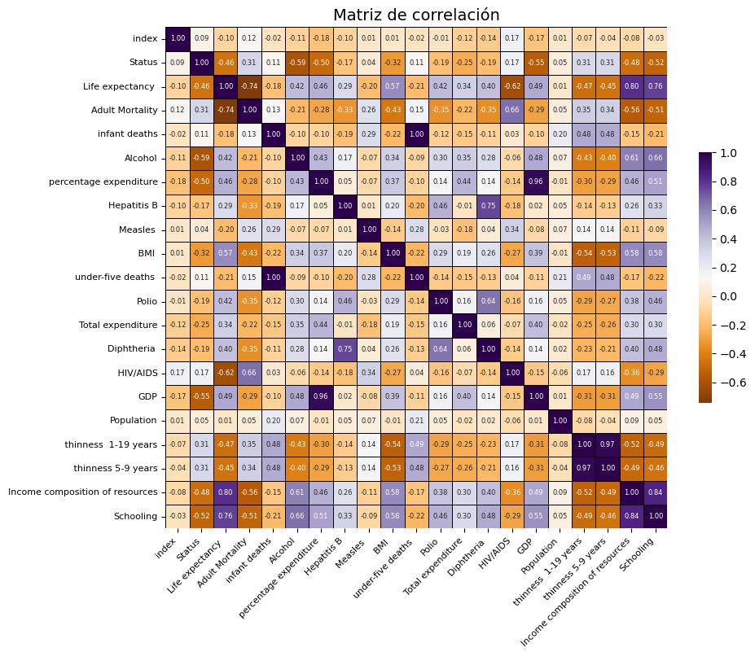

```python
# Calculate the correlation matrix
cor_matrix = data2010.corr()

# Plot the correlation matrix
plt.figure(figsize=(10, 8))
sns.heatmap(cor_matrix, annot=True, cmap='PuOr', cbar_kws={'shrink': .5},
            square=True, fmt=".2f", annot_kws={"size": 6}, linewidths=0.5,
            linecolor='black')

# Add a title
plt.title("Matriz de correlación", fontsize=14)
plt.xticks(rotation=45, ha='right', fontsize=8)
plt.yticks(fontsize=8)
plt.show()
```

```python
from IPython.display import Image, display
```

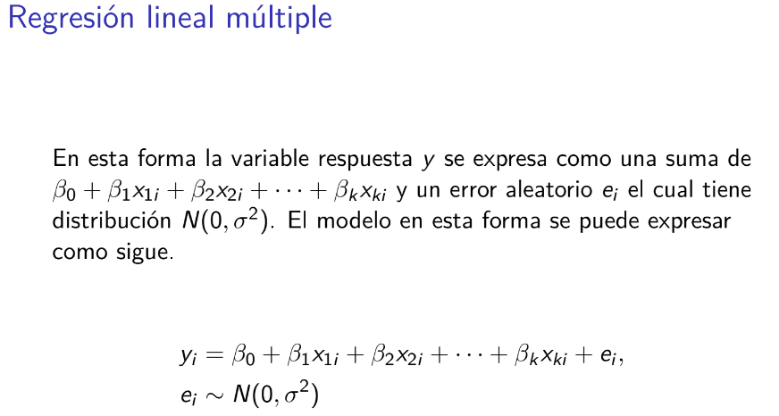

```python
Image(filename="img/RLMformula.png")
```

**UN MODELO CON TODAS LAS VARIABLES**

```python
# Seleccionar las variables predictoras (excluyendo la variable de respuesta)
X = data2010.drop(columns=["Life expectancy "])

# Variable de respuesta
y = data2010["Life expectancy "]

# Agregar una constante para la intersección
X = sm.add_constant(X)

# Ajustar el modelo de regresión lineal múltiple
model = sm.OLS(y, X).fit()

# Resumen del modelo
print(model.summary())
```

```
                            OLS Regression Results
==============================================================================
Dep. Variable:       Life expectancy    R-squared:                       0.859
Model:                            OLS   Adj. R-squared:                  0.832
Method:                 Least Squares   F-statistic:                     32.54
Date:                Mon, 28 Oct 2024   Prob (F-statistic):           1.89e-36
Time:                        18:44:20   Log-Likelihood:                -334.51
No. Observations:                 128   AIC:                             711.0
Df Residuals:                     107   BIC:                             770.9
Df Model:                          20
Covariance Type:            nonrobust
===================================================================================================
                                      coef    std err          t      P>|t|      [0.025      0.975]
---------------------------------------------------------------------------------------------------
const                              51.2690      3.346     15.321      0.000      44.635      57.903
index                               0.0002      0.000      0.458      0.648      -0.001       0.001
Status                             -1.5343      1.314     -1.168      0.246      -4.139       1.070
Adult Mortality                    -0.0122      0.004     -2.773      0.007      -0.021      -0.003
infant deaths                       0.0752      0.039      1.916      0.058      -0.003       0.153
Alcohol                            -0.2413      0.139     -1.736      0.086      -0.517       0.034
percentage expenditure             -0.0002      0.001     -0.203      0.839      -0.002       0.001
Hepatitis B                        -0.0151      0.021     -0.723      0.471      -0.057       0.026
Measles                          2.109e-05    3.2e-05      0.658      0.512   -4.24e-05    8.46e-05
 BMI                                0.0170      0.021      0.800      0.425      -0.025       0.059
under-five deaths                  -0.0567      0.029     -1.947      0.054      -0.114       0.001
Polio                               0.0112      0.020      0.548      0.585      -0.029       0.052
Total expenditure                   0.3691      0.160      2.308      0.023       0.052       0.686
Diphtheria                          0.0184      0.026      0.711      0.479      -0.033       0.070
 HIV/AIDS                          -0.7530      0.135     -5.559      0.000      -1.022      -0.485
GDP                              7.048e-05      0.000      0.525      0.600      -0.000       0.000
Population                      -4.488e-09   1.01e-08     -0.446      0.656   -2.44e-08    1.54e-08
 thinness  1-19 years               0.0680      0.310      0.219      0.827      -0.547       0.683
 thinness 5-9 years                -0.1039      0.291     -0.357      0.722      -0.680       0.473
Income composition of resources    16.1604      3.823      4.227      0.000       8.582      23.739
Schooling                           0.7419      0.259      2.863      0.005       0.228       1.256
==============================================================================
Omnibus:                        2.126   Durbin-Watson:                   2.220
Prob(Omnibus):                  0.345   Jarque-Bera (JB):                1.851
Skew:                          -0.011   Prob(JB):                        0.396
Kurtosis:                       3.589   Cond. No.                     4.89e+08
==============================================================================

Notes:
[1] Standard Errors assume that the covariance matrix of the errors is correctly specified.
[2] The condition number is large, 4.89e+08. This might indicate that there are
strong multicollinearity or other numerical problems.
```

**BUSCANDO UN MODELO EN SERIO**

### Criterio de Información de Akaike (AIC) en una Regresión Lineal

El **Criterio de Información de Akaike (AIC)** es una medida para evaluar modelos estadísticos, comúnmente utilizada en regresiones lineales.  
El AIC estima la calidad de un modelo en función de su ajuste a los datos y la complejidad del modelo, con el objetivo de identificar el modelo que mejor generaliza.

donde:

- ( k ) es el número de parámetros en el modelo,
- ( \hat{L} ) es el valor máximo de la función de verosimilitud del modelo.

**Interpretación**: Al comparar modelos que se ajustan a los mismos datos, el modelo con el **AIC más bajo** es el preferido,  
ya que indica un mejor balance entre el ajuste y la simplicidad del modelo.

### Criterio de Información Bayesiano (BIC) en una Regresión Lineal

El **Criterio de Información Bayesiano (BIC)** es una medida similar al AIC, también utilizada para seleccionar modelos en función de su ajuste  
y complejidad, pero con una penalización más fuerte para modelos con mayor número de parámetros.

donde:

- ( n ) es el número de observaciones en el conjunto de datos,
- ( k ) es el número de parámetros en el modelo,
- ( \hat{L} ) es el valor máximo de la función de verosimilitud del modelo.

**Interpretación**: Al comparar modelos, el **BIC más bajo** es preferible, ya que indica un modelo que equilibra el ajuste y la simplicidad,  
aunque penaliza más fuertemente los modelos complejos en comparación con el AIC, favoreciendo así modelos más parsimoniosos.

```python
from sklearn.feature_selection import RFE
from sklearn.linear_model import LinearRegression
from sklearn.metrics import mean_squared_error

# Define el modelo
model = LinearRegression()

# Define la matriz de predictores (X) y la variable respuesta (y)
X = data2010.drop(columns=['Life expectancy '])  # Asegúrate de que 'Life expectancy' es tu variable objetivo
y = data2010['Life expectancy ']

# Configura Recursive Feature Elimination (RFE)
selector = RFE(estimator=model, n_features_to_select=5, step=1)  # Puedes ajustar n_features_to_select
selector = selector.fit(X, y)

# Muestra las variables seleccionadas
selected_features = X.columns[selector.support_]
print("Selected features:", selected_features)

# Crea un nuevo modelo usando solo las variables seleccionadas
X_selected = X[selected_features]
model.fit(X_selected, y)

# Evalúa el modelo
y_pred = model.predict(X_selected)
mse = mean_squared_error(y, y_pred)
```

```
Selected features: Index(['Status', 'Total expenditure', ' HIV/AIDS',
       'Income composition of resources', 'Schooling'],
      dtype='object')
```

```python
# Crea un nuevo modelo usando solo las variables seleccionadas
X_selected = X[selected_features]
model.fit(X_selected, y)

# Evalúa el modelo
y_pred = model.predict(X_selected)
mse = mean_squared_error(y, y_pred)
print(mse)
```

```
14.207583555475642
```

```python
# Crear un nuevo modelo de OLS con statsmodels usando solo las variables seleccionadas
X_selected = X[selected_features]
X_selected = sm.add_constant(X_selected)  # Agrega constante para la intersección

# Ajusta el modelo de regresión lineal
ols_model = sm.OLS(y, X_selected).fit()

# Imprime el resumen del modelo
print(ols_model.summary())
```

```
                            OLS Regression Results
==============================================================================
Dep. Variable:       Life expectancy    R-squared:                       0.816
Model:                            OLS   Adj. R-squared:                  0.808
Method:                 Least Squares   F-statistic:                     108.2
Date:                Mon, 28 Oct 2024   Prob (F-statistic):           3.96e-43
Time:                        18:44:21   Log-Likelihood:                -351.47
No. Observations:                 128   AIC:                             714.9
Df Residuals:                     122   BIC:                             732.0
Df Model:                           5
Covariance Type:            nonrobust
===================================================================================================
                                      coef    std err          t      P>|t|      [0.025      0.975]
---------------------------------------------------------------------------------------------------
const                              46.3689      2.590     17.903      0.000      41.242      51.496
Status                             -0.9593      1.187     -0.808      0.421      -3.310       1.391
Total expenditure                   0.3898      0.151      2.589      0.011       0.092       0.688
 HIV/AIDS                          -1.0175      0.108     -9.442      0.000      -1.231      -0.804
Income composition of resources    18.1517      3.788      4.791      0.000      10.652      25.651
Schooling                           0.9342      0.232      4.030      0.000       0.475       1.393
==============================================================================
Omnibus:                        4.384   Durbin-Watson:                   2.158
Prob(Omnibus):                  0.112   Jarque-Bera (JB):                4.763
Skew:                          -0.204   Prob(JB):                       0.0924
Kurtosis:                       3.853   Cond. No.                         156.
==============================================================================

Notes:
[1] Standard Errors assume that the covariance matrix of the errors is correctly specified.
```

```python
X = data2010[["Total expenditure"," HIV/AIDS", "Income composition of resources", "Schooling"]]

# Variable de respuesta
y = data2010["Life expectancy "]

# Agregar una constante para la intersección
X = sm.add_constant(X)

# Ajustar el modelo de regresión lineal múltiple
model4 = sm.OLS(y, X).fit()

# Resumen del modelo
print(model4.summary())
```

```
                            OLS Regression Results
==============================================================================
Dep. Variable:       Life expectancy    R-squared:                       0.815
Model:                            OLS   Adj. R-squared:                  0.809
Method:                 Least Squares   F-statistic:                     135.4
Date:                Mon, 28 Oct 2024   Prob (F-statistic):           4.40e-44
Time:                        18:44:21   Log-Likelihood:                -351.81
No. Observations:                 128   AIC:                             713.6
Df Residuals:                     123   BIC:                             727.9
Df Model:                           4
Covariance Type:            nonrobust
===================================================================================================
                                      coef    std err          t      P>|t|      [0.025      0.975]
---------------------------------------------------------------------------------------------------
const                              44.7761      1.677     26.695      0.000      41.456      48.096
Total expenditure                   0.4035      0.149      2.701      0.008       0.108       0.699
 HIV/AIDS                          -1.0180      0.108     -9.459      0.000      -1.231      -0.805
Income composition of resources    18.4242      3.768      4.890      0.000      10.966      25.883
Schooling                           0.9761      0.226      4.326      0.000       0.529       1.423
==============================================================================
Omnibus:                        3.880   Durbin-Watson:                   2.159
Prob(Omnibus):                  0.144   Jarque-Bera (JB):                4.267
Skew:                          -0.145   Prob(JB):                        0.118
Kurtosis:                       3.846   Cond. No.                         155.
==============================================================================

Notes:
[1] Standard Errors assume that the covariance matrix of the errors is correctly specified.
```

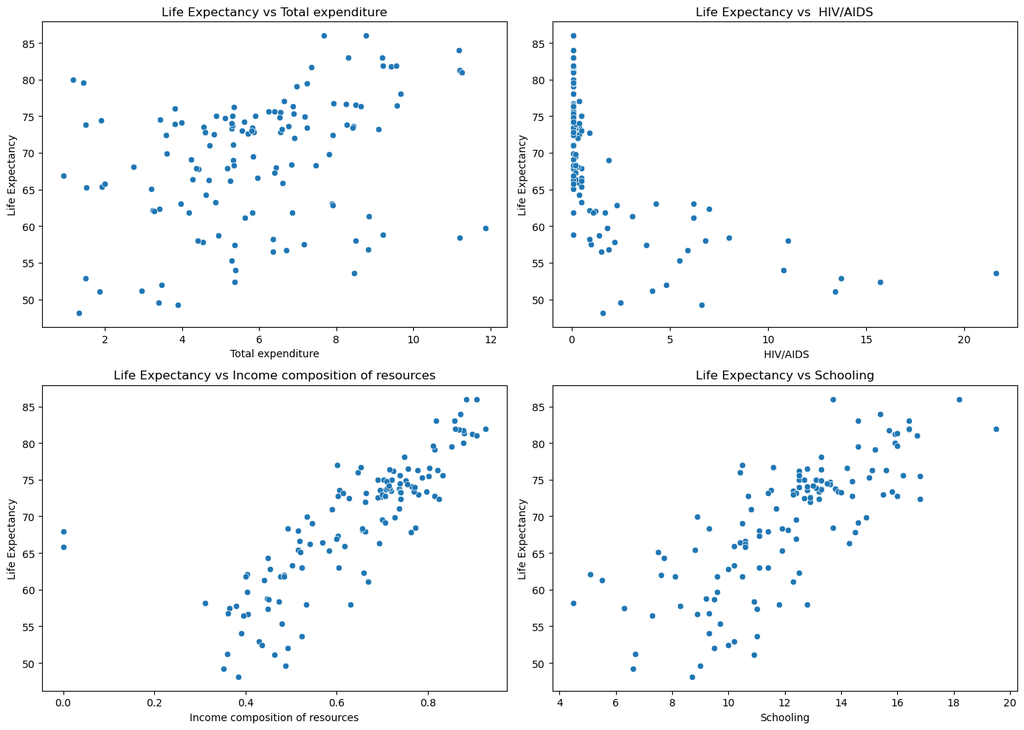

```python
# Lista de variables independientes
variables = ["Total expenditure", " HIV/AIDS", "Income composition of resources", "Schooling"]


# Crear gráficos de dispersión
plt.figure(figsize=(14, 10))
for i, var in enumerate(variables, 1):
    plt.subplot(2, 2, i)
    sns.scatterplot(x=data2010[var], y=data2010["Life expectancy "])
    plt.title(f"Life Expectancy vs {var}")
    plt.xlabel(var)
    plt.ylabel("Life Expectancy")

plt.tight_layout()
plt.show()
```

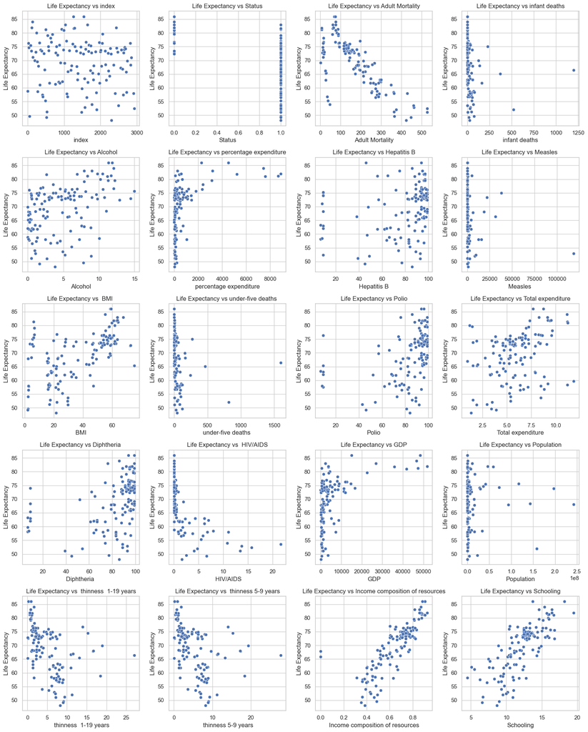

```python
# Configurar estilo de los gráficos
sns.set(style="whitegrid")

# Excluir la columna de la variable predicha y listar el resto de variables independientes
variables = [col for col in data2010.columns if col != "Life expectancy "]

# Definir dimensiones de la figura para ajustarse al número de variables
num_vars = len(variables)
num_rows = (num_vars + 3) // 4  # Aproximar a filas necesarias de 4 columnas

# Crear gráficos de dispersión
plt.figure(figsize=(16, num_rows * 4))
for i, var in enumerate(variables, 1):
    plt.subplot(num_rows, 4, i)
    sns.scatterplot(x=data2010[var], y=data2010["Life expectancy "])
    plt.title(f"Life Expectancy vs {var}")
    plt.xlabel(var)
    plt.ylabel("Life Expectancy")

plt.tight_layout()
plt.show()
```

### SUPUESTOS

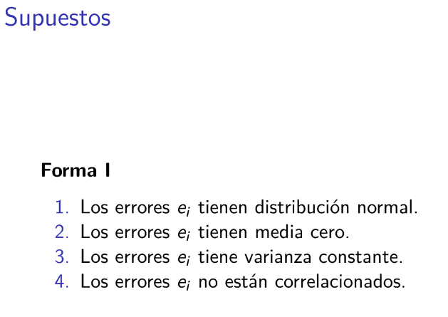

```python
Image(filename="img/supuestosE.png")
```

```python
### SUPUESTO 1
#### NORMALIDAD DE LOS ERRORES
```

```python
resid_val=model4.resid

fitted_val=model4.predict()

## promedio esperado de los residuos
# E(resid) = 0

model4.resid.mean()
```

```
-2.6867397195928788e-14
```

```python
from scipy import stats
```

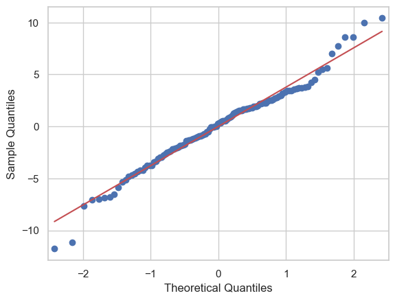

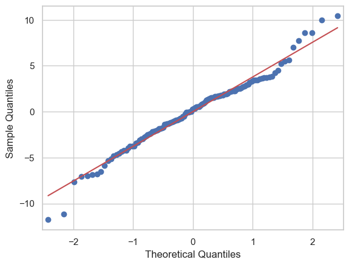

```python
sm.qqplot(resid_val, line="s")
```

```python
stats.shapiro(resid_val)
```

```
ShapiroResult(statistic=0.9828255772590637, pvalue=0.10522856563329697)
```

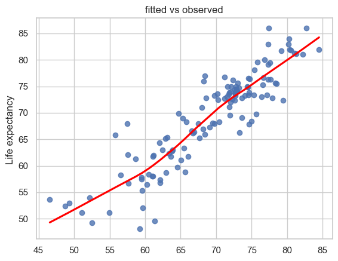

```python
sns.regplot(x=fitted_val, y=y, lowess=True, line_kws={"color":"red"})
plt.title("fitted vs observed")
```

### SUPUESTO 2

### Homocedasticidad o igualdad de varianzas

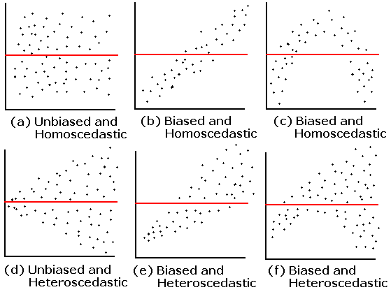

```python
Image(filename="img/heterocedasticity.png")
```

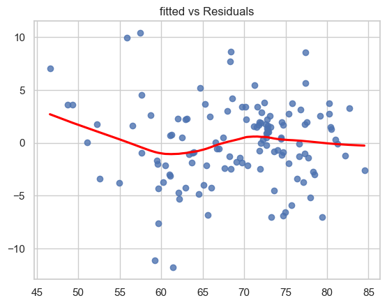

```python
sns.regplot(x=fitted_val, y=resid_val, lowess=True, line_kws={"color":"red"})
plt.title("fitted vs Residuals")

##Lo importante en este punto es que no haya un patron
```

```python
### Es mejor utilizar reiduos estandarizados.
```

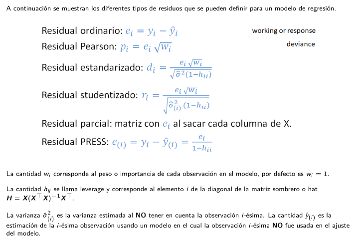

```python
Image(filename="img/Rstandarizados.png")
```

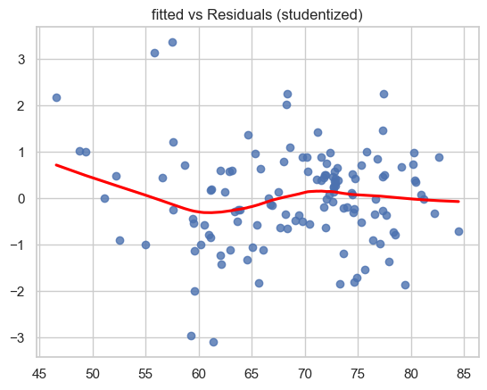

```python
resid_stand = model4.get_influence().resid_studentized_internal

sns.regplot(x=fitted_val, y=resid_stand, lowess=True, line_kws={"color":"red"})
plt.title("fitted vs Residuals (studentized)")
```

```python
from statsmodels.stats.diagnostic import het_breuschpagan

bp_test = het_breuschpagan(resid_val, model4.model.exog)

print(bp_test)
print("//nBreusch-Pagan test: pvalue =", bp_test[1])
```

```
(23.759824612981305, 8.92344489145751e-05, 7.008954120967075, 4.0712159750116414e-05)
//nBreusch-Pagan test: pvalue = 8.92344489145751e-05
```

```python
### SUPUESTO 3
### NO MULTICOLINEALIDAD
```

El **Variance Inflarion Factor** (VIF) es una medida que evalúa la colinealidad entre variables independientes en un modelo de regresión.  
Un VIF alto indica que una variable está altamente correlacionada con otras variables independientes, lo cual puede inflar  
la varianza de los coeficientes y hacer que el modelo sea inestable o que sus coeficientes sean difíciles de interpretar.

### Interpretación básica:

- **VIF = 1**: No hay colinealidad.
- **VIF entre 1 y 5**: Colinealidad moderada; generalmente aceptable.
- **VIF > 5 o 10**: Colinealidad alta; podría ser problemático y sugiere considerar la eliminación o combinación de variables.

Un VIF elevado en una variable puede implicar que los cambios en los coeficientes se deben a redundancias con otras variables,  
afectando la confiabilidad del modelo.

```python
from statsmodels.stats.outliers_influence import variance_inflation_factor
```

```python
# Excluir la constante antes de calcular el VIF
X_no_const = X.drop(columns=['const'])

# Calcular el VIF para cada columna en X_no_const
vif = [variance_inflation_factor(X_no_const.values, i) for i in range(X_no_const.shape[1])]

# Crear un DataFrame con los VIFs y los nombres de las columnas sin la constante
vif_model4 = pd.DataFrame({"VIF": vif}, index=X_no_const.columns)

vif_model4
```

|  | VIF |
| --- | --- |
| Total expenditure | 7.491880 |
| HIV/AIDS | 1.216211 |
| Income composition of resources | 52.626348 |
| Schooling | 55.542756 |

```python
### SACAMOS A SCHOOLING DEL MODELO
```

```python
X = data2010[["Total expenditure"," HIV/AIDS", "Income composition of resources"]]

# Variable de respuesta
y = data2010["Life expectancy "]

# Agregar una constante para la intersección
X = sm.add_constant(X)

# Ajustar el modelo de regresión lineal múltiple
model3 = sm.OLS(y, X).fit()

# Resumen del modelo
print(model3.summary())
```

```
                            OLS Regression Results
==============================================================================
Dep. Variable:       Life expectancy    R-squared:                       0.787
Model:                            OLS   Adj. R-squared:                  0.782
Method:                 Least Squares   F-statistic:                     152.6
Date:                Mon, 28 Oct 2024   Prob (F-statistic):           1.91e-41
Time:                        18:44:24   Log-Likelihood:                -360.87
No. Observations:                 128   AIC:                             729.7
Df Residuals:                     124   BIC:                             741.1
Df Model:                           3
Covariance Type:            nonrobust
===================================================================================================
                                      coef    std err          t      P>|t|      [0.025      0.975]
---------------------------------------------------------------------------------------------------
const                              47.8800      1.621     29.542      0.000      44.672      51.088
Total expenditure                   0.4598      0.159      2.890      0.005       0.145       0.775
 HIV/AIDS                          -1.0012      0.115     -8.708      0.000      -1.229      -0.774
Income composition of resources    31.6254      2.363     13.386      0.000      26.949      36.302
==============================================================================
Omnibus:                       33.298   Durbin-Watson:                   2.118
Prob(Omnibus):                  0.000   Jarque-Bera (JB):              133.833
Skew:                           0.805   Prob(JB):                     8.68e-30
Kurtosis:                       7.744   Cond. No.                         50.3
==============================================================================

Notes:
[1] Standard Errors assume that the covariance matrix of the errors is correctly specified.
```

```python
X_no_const = X.drop(columns=['const'])

# Calcular el VIF para cada columna en X_no_const
vif = [variance_inflation_factor(X_no_const.values, i) for i in range(X_no_const.shape[1])]

# Crear un DataFrame con los VIFs y los nombres de las columnas sin la constante
vif_model3 = pd.DataFrame({"VIF": vif}, index=X_no_const.columns)

vif_model3
```

|  | VIF |
| --- | --- |
| Total expenditure | 7.154767 |
| HIV/AIDS | 1.154885 |
| Income composition of resources | 6.893051 |

```python
## Ensayamos incorporar una nueva variable, pero solo empeoramos el modelo.
```

```python
X = data2010[["Total expenditure"," HIV/AIDS", "Income composition of resources","under-five deaths "]]

# Variable de respuesta
y = data2010["Life expectancy "]

# Agregar una constante para la intersección
X = sm.add_constant(X)

# Ajustar el modelo de regresión lineal múltiple
model4NEW = sm.OLS(y, X).fit()

# Resumen del modelo
print(model4NEW.summary())
```

```
                            OLS Regression Results
==============================================================================
Dep. Variable:       Life expectancy    R-squared:                       0.791
Model:                            OLS   Adj. R-squared:                  0.785
Method:                 Least Squares   F-statistic:                     116.7
Date:                Mon, 28 Oct 2024   Prob (F-statistic):           6.77e-41
Time:                        18:44:25   Log-Likelihood:                -359.47
No. Observations:                 128   AIC:                             728.9
Df Residuals:                     123   BIC:                             743.2
Df Model:                           4
Covariance Type:            nonrobust
===================================================================================================
                                      coef    std err          t      P>|t|      [0.025      0.975]
---------------------------------------------------------------------------------------------------
const                              48.5304      1.657     29.281      0.000      45.250      51.811
Total expenditure                   0.4333      0.159      2.728      0.007       0.119       0.748
 HIV/AIDS                          -1.0043      0.114     -8.795      0.000      -1.230      -0.778
Income composition of resources    31.1254      2.366     13.155      0.000      26.442      35.809
under-five deaths                  -0.0037      0.002     -1.647      0.102      -0.008       0.001
==============================================================================
Omnibus:                       30.278   Durbin-Watson:                   2.114
Prob(Omnibus):                  0.000   Jarque-Bera (JB):              111.542
Skew:                           0.744   Prob(JB):                     6.01e-25
Kurtosis:                       7.324   Cond. No.                     1.31e+03
==============================================================================

Notes:
[1] Standard Errors assume that the covariance matrix of the errors is correctly specified.
[2] The condition number is large, 1.31e+03. This might indicate that there are
strong multicollinearity or other numerical problems.
```

```python
X = data2010[["Total expenditure"," HIV/AIDS", "Schooling"]]

# Variable de respuesta
y = data2010["Life expectancy "]

# Agregar una constante para la intersección
X = sm.add_constant(X)

# Ajustar el modelo de regresión lineal múltiple
model3bis = sm.OLS(y, X).fit()

# Resumen del modelo
print(model3bis.summary())
```

```
                            OLS Regression Results
==============================================================================
Dep. Variable:       Life expectancy    R-squared:                       0.779
Model:                            OLS   Adj. R-squared:                  0.774
Method:                 Least Squares   F-statistic:                     145.7
Date:                Mon, 28 Oct 2024   Prob (F-statistic):           1.78e-40
Time:                        18:44:25   Log-Likelihood:                -363.18
No. Observations:                 128   AIC:                             734.4
Df Residuals:                     124   BIC:                             745.8
Df Model:                           3
Covariance Type:            nonrobust
=====================================================================================
                        coef    std err          t      P>|t|      [0.025      0.975]
-------------------------------------------------------------------------------------
const                45.3612      1.821     24.909      0.000      41.757      48.966
Total expenditure     0.4809      0.162      2.974      0.004       0.161       0.801
 HIV/AIDS            -1.1444      0.114    -10.065      0.000      -1.369      -0.919
Schooling             1.8697      0.144     12.979      0.000       1.585       2.155
==============================================================================
Omnibus:                        2.880   Durbin-Watson:                   2.093
Prob(Omnibus):                  0.237   Jarque-Bera (JB):                2.332
Skew:                          -0.268   Prob(JB):                        0.312
Kurtosis:                       3.388   Cond. No.                         68.7
==============================================================================

Notes:
[1] Standard Errors assume that the covariance matrix of the errors is correctly specified.
```

```python
X_no_const = X.drop(columns=['const'])

# Calcular el VIF para cada columna en X_no_const
vif = [variance_inflation_factor(X_no_const.values, i) for i in range(X_no_const.shape[1])]

# Crear un DataFrame con los VIFs y los nombres de las columnas sin la constante
vif_model3bis = pd.DataFrame({"VIF": vif}, index=X_no_const.columns)

vif_model3bis
```

|  | VIF |
| --- | --- |
| Total expenditure | 7.372476 |
| HIV/AIDS | 1.151500 |
| Schooling | 7.275045 |